# Simulating effects

## The data generating model

When we trying to estimate effects, it makes snese to think about the data generating model. Differently than simply assumeing an effect size for specific statistical tests, this implies formulating how we think the data were are planning to collect come about. This means more specifically to think about

- observed (and unobserved variables)
- relationships between variables
- the strenght of these relationships

Here is my current understaning of the situation:

Trough a *TSST* manipulation we can induce *negative affect*. A drug manipulation with an *opioid* leads to a *reduction of negative affect*, which in turn leads to more *wanting* but not nessesarily *liking* (of opioid).

A visual representation of this model looks as follows:

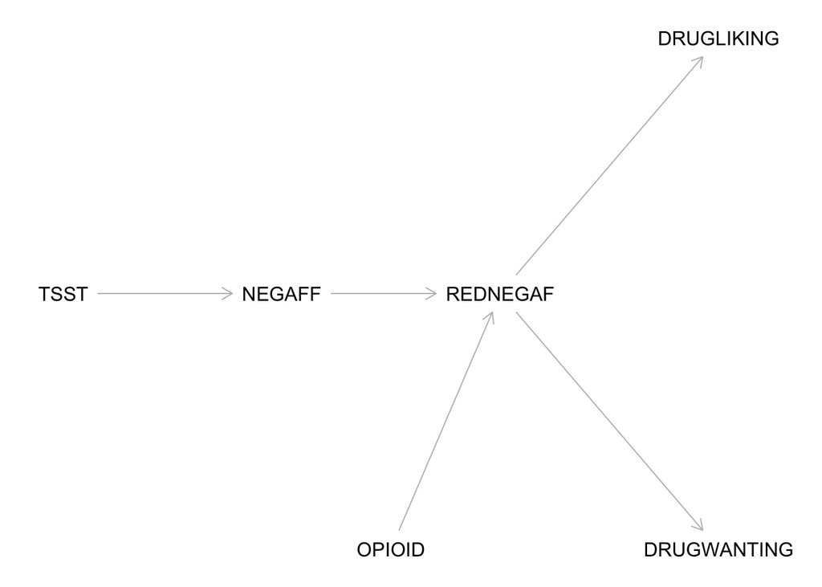

```r
DGP = dagitty(
"dag {
  TSST    [pos=\"0,0\"]
  NEGAFF  [pos=\"1,0\"]
  OPIOID  [pos=\"1.5,1\"]
  REDNEGAF [pos=\"2,0\"]
  DRUGWANTING [pos=\"3,1\"]
  DRUGLIKING  [pos=\"3,-1\"]
  TSST -> NEGAFF
  NEGAFF -> REDNEGAF
  OPIOID -> REDNEGAF
  REDNEGAF -> DRUGWANTING
  REDNEGAF -> DRUGLIKING
}")
exposures(DGP) = c("TSST","OPIOID")
outcomes(DGP) = c("REDNEGAF","WANTING","LIKING")
plot(DGP)
```

## Simulating data

In the simplest case, one could simply assume that all variables in the model are normally distributed. This assumptions does not seem to fit well, because the TSST and OPIOD manipulations are binary. Moreover, it is not clear if negatice affect is just the opposite pole of positive affect. This is important, becuase if negative affect were just one end of a one-dimensional construct, this would imply that if opioids reduce negative affect they should also increase positive affect.

For now, we’ll work under the assumption that opioids primarily reduce negative affect, without also strengthening positiuve affect. This means that we need to model `NEFAGG` wit a lower bound of zero.

```r
N = 1000
TSST = sort(rep(c(0,1),N/2))
```

Next, we model negative affect as an effect of TSST plus som noise:

```r
eTSST = 2.5
baseNEGAFF = -2.5
sdNEGAFF = .5

NEGAFF = inv.logit(TSST * eTSST +
                   rnorm(N,
                         mean = baseNEGAFF,
                         sd = sdNEGAFF))
```

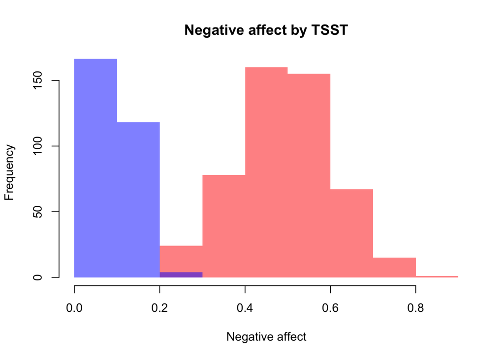

The `ìnv.logit` function is the same inverse logit that is also used in logistic regressions. we use this function to get from uncontrained normally distributed values to ratings of negative affect that are bound between zero and a maximum value.

We can get an approximation of the expected effect sizes by calculating Cohen’s h from the difference of expexted proportions of the maximal negative affect between the TSST and no TSST groups:

```r
mTSST = inv.logit(baseNEGAFF)
mNOTSST = inv.logit(baseNEGAFF + eTSST)
Cohens_h = diff(
2 * asin(
  sqrt(c(mNOTSST,mTSST))
  )
)
sprintf("Cohen´s h = %.1f",Cohens_h)
```

```
## [1] "Cohen´s h = -1.0"
```

The issue with this effect size measure is that it does not take into account the error variance. I’ll have to look into this again later. One possibility is to calculate mean and variance of the two beta distributions for the TSST conditions and pluf these into the formula for Cohen’s d.

Next we define the opioid intervention, such that participants with and without TSST intervention receive opioids

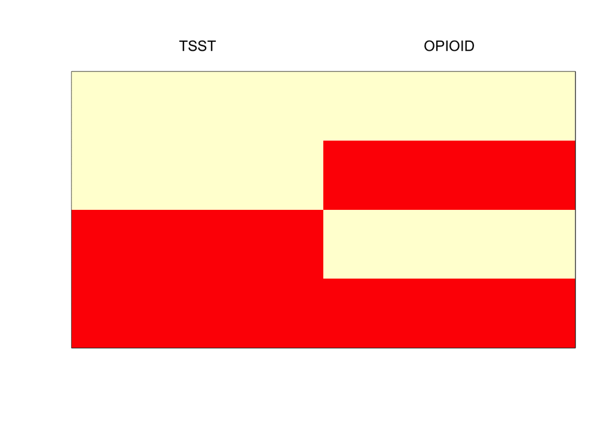

```r
OPIOID = rep(sort(rep(c(0,1),
                      N/4)),
             2)
image(rbind(TSST,OPIOID),
      xaxt = "n",
      yaxt = "n")
axis(3, at = c(0,1),
     labels = c("TSST","OPIOID"),
     lwd = 0,
     cex = 2)
```

Now we can define reduction in negative affect as negative affect after the effect of drug minus negative affect before drug. We do some mathematical tricks to stasy in the bounds and also add random error:

```r
NEGAF_AFTERDRUG = inv.logit(logit(NEGAFF) - OPIOID + rnorm(N, sd = .5))
REDNEGAF =  NEGAF_AFTERDRUG - NEGAFF
```

And we plot to see if we get the expected results:

```r
dt = data.table(TSST,OPIOID,NEGAFF,REDNEGAF)
dt[,OPIOID := factor(OPIOID)]
dt[,TSST := factor(TSST)]
tbl = dt[,list(mREDNEGAF = mean(REDNEGAF), mNEGAFF = mean(NEGAFF)), by = c("TSST","OPIOID")]
kable(tbl, digits = 2)
```

| TSST | OPIOID | mREDNEGAF | mNEGAFF |
| --- | --- | --- | --- |
| 0 | 0 | 0.00 | 0.08 |
| 0 | 1 | -0.04 | 0.08 |
| 1 | 0 | 0.00 | 0.49 |
| 1 | 1 | -0.21 | 0.49 |

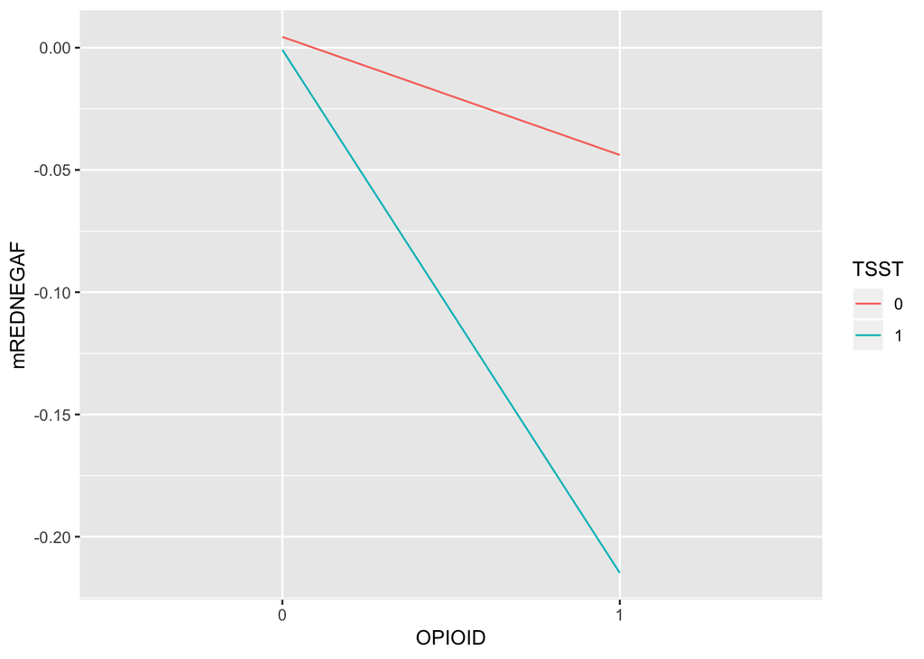

```r
ggplot(tbl,aes(x = OPIOID, y = mREDNEGAF, group = TSST, color = TSST)) + geom_line()
```

```r
DRUGWANTING = REDNEGAF
```

Now we can repeat this process 1000 times to see a distribution of effects:

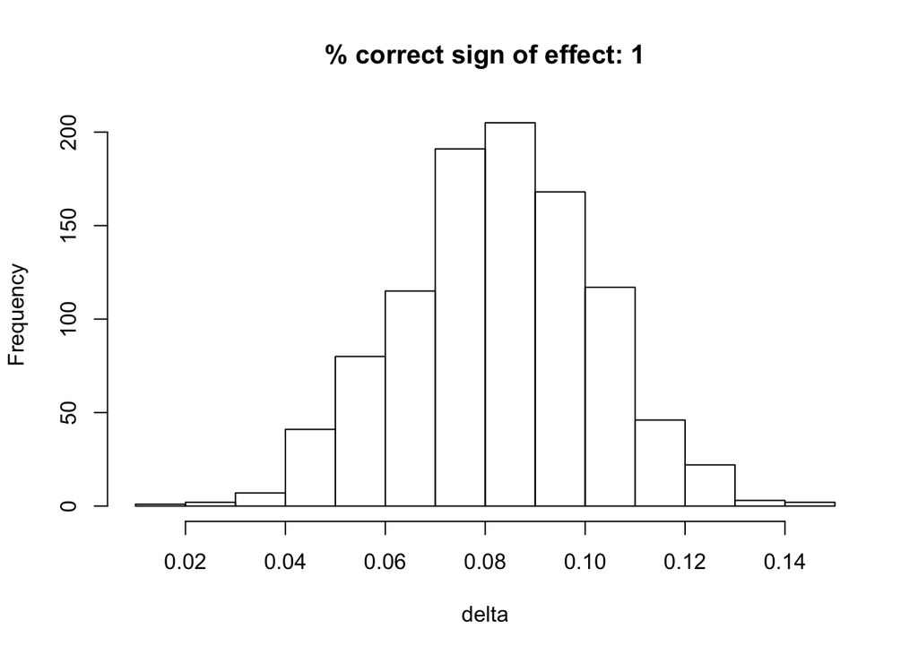

```r
K = 1000
OPIOID = rep(sort(rep(c(0,1),
                      N/4)),
             2)

TSST = sort(rep(c(0,1),N/2))
reduction = matrix(NA,ncol = 2, nrow = K)
colnames(reduction) = c("no TSST","TSST")
for (k in 1:K) {
  NEGAFF = inv.logit(TSST*3+rnorm(N, mean = -2))
  REDNEGAF = NEGAFF - inv.logit(logit(NEGAFF) - OPIOID + rnorm(N))
  dt = data.table(TSST,OPIOID,NEGAFF,REDNEGAF)
  dt[,OPIOID := factor(OPIOID)]
  dt[,TSST := factor(TSST)]
  tbl = dt[,list(mREDNEGAF = mean(REDNEGAF), mNEGAFF = mean(NEGAFF)), by = c("TSST","OPIOID")]

  reduction[k,] = tbl[,diff(mREDNEGAF), by = "TSST"][["V1"]]
}

delta = reduction[,"TSST"]-reduction[,"no TSST"]
hist(delta,
     main = paste("% correct sign of effect:",round(mean(delta > 0),digits = 2)))
abline(v = 0, col = "red")
```

- discuss if the DGP reflects what you think
- gather more information about the effect size of the TSST and opioid manipulation

Once this is done, we can extend the simulations to include uncertainty about effect sizes and downstream effects, like the effect on wanting vs. liking.